# Practical 1 — From counts to clusters

BINF90004 Bioinformatics Case Studies · scRNA-seq

# Before you start

**You have 65 minutes. You are not expected to finish every chunk.**

There is one **hard sync point**, marked in red below. When we reach it, everyone loads the same checkpoint file and moves on together — whether or not your own code has finished. Nobody gets left behind, so do not panic if you fall behind.

Three sections are marked **DECISION**. These are the point of the practical. Each asks you to make a choice that the data alone does not determine, and to justify it to the person sitting next to you. If your R is not working, **you can still do all three** — they are answered by looking and thinking, not by running code.

```r
library(Seurat)
library(harmony)
library(clustree)
library(ggplot2)
library(dplyr)
library(patchwork)

# Not optional. SCTransform hands large objects to parallel workers, and the
# default 500 MB ceiling is too low - without this you get a
# "total size of globals exceeds maximum allowed size" error partway through
# section 3, which looks alarming and is not your fault.
options(future.globals.maxSize = 8 * 1024^3)

# Resolve the data folder whether you knit from practicals/ or run
# interactively with the repo root as your working directory.
DATA <- if (dir.exists("data")) "data" else "../data"
```

```r
group_cols <- c(fetal = "#4E79A7", young = "#F28E2B", adult = "#59A14F")
sample_cols <- c(
    f1 = "#9ECAE1", f2 = "#6BAED6", f3 = "#3182BD",
    y1 = "#FDD0A2", y2 = "#FDAE6B", y3 = "#E6550D",
    a1 = "#C7E9C0", a2 = "#A1D99B", a3 = "#31A354"
)
```

# 1. The data

Human heart, single-**nucleus** RNA-seq, from [Sim et al. (2021), *Circulation*](https://doi.org/10.1161/CIRCULATIONAHA.120.051921) — a study of how the human heart matures. Nine donors across three developmental stages:

| Group | Donors | Age |
| --- | --- | --- |
| foetal | f1, f2, f3 | 19–20 weeks |
| young | y1, y2, y3 | 4–14 years |
| adult | a1, a2, a3 | 35–42 years |

Note **snRNA-seq**, not scRNA-seq: nuclei were isolated rather than whole cells. Keep that in mind — it will matter within about ten minutes.

```r
seu <- readRDS(file.path(DATA, "P1_start.rds"))
seu
```

```
## An object of class Seurat
## 18953 features across 7999 samples within 1 assay
## Active assay: RNA (18953 features, 0 variable features)
##  1 layer present: counts
```

Some work has been done for you, to save time — none of it involving a choice: cells with <200 genes and genes in <3 cells were dropped, gene annotation was attached, QC metrics were computed, uninformative gene classes (ribosomal, unannotated, sex-chromosome) were removed, and the object was downsampled to 8,000 nuclei stratified by donor.

That last step preserves the donors’ relative sizes, which are strikingly uneven — the adult samples are genuinely much smaller than the foetal ones. That imbalance is real, and it will matter twice today.

**No cell filtering has been done.** That is your first decision.

```r
head(seu@meta.data)
```

|  | orig.ident | nCount_RNA | nFeature_RNA | sample | group | sex | percent.mt | percent.ribo |
| --- | --- | --- | --- | --- | --- | --- | --- | --- |
| AAACGAAAGAGGCCAT_f1 | heart | 1109 | 744 | f1 | fetal | m | 2.25428314 | 7.5743913 |
| AAAGAACAGCAGTAAT_f1 | heart | 9855 | 3651 | f1 | fetal | m | 0.23338407 | 0.4566210 |
| AAAGAACGTCATACCA_f1 | heart | 12744 | 4274 | f1 | fetal | m | 0.56497175 | 0.9808537 |
| AAAGAACTCTCCATAT_f1 | heart | 9861 | 4163 | f1 | fetal | m | 0.51718893 | 0.4360613 |
| AAAGGATTCCAATGCA_f1 | heart | 12597 | 3605 | f1 | fetal | m | 0.06350718 | 0.6747638 |
| AAAGGATTCTCGCTTG_f1 | heart | 14904 | 4623 | f1 | fetal | m | 0.16103060 | 0.8521202 |

```r
table(seu$sample, seu$group)
```

```
##
##      adult fetal young
##   a1   644     0     0
##   a2   499     0     0
##   a3   248     0     0
##   f1     0  1226     0
##   f2     0  1618     0
##   f3     0  1258     0
##   y1     0     0   653
##   y2     0     0   821
##   y3     0     0  1032
```

Two metadata columns matter now:

- `nCount_RNA` — total UMI counts per nucleus (library size)
- `nFeature_RNA` — number of genes detected per nucleus

and two we computed:

- `percent.mt` — % of counts from mitochondrial genes
- `percent.ribo` — % of counts from ribosomal protein genes

# 2. Quality control

## 2.1 Look before you filter

The single most common QC mistake is applying a threshold you read somewhere without first looking at your own data. So: look first.

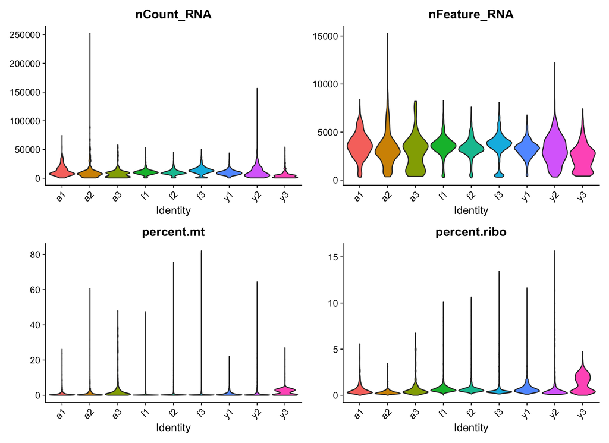

```r
VlnPlot(seu, features = c("nCount_RNA", "nFeature_RNA", "percent.mt", "percent.ribo"),
        group.by = "sample", pt.size = 0, ncol = 2) &
    theme(axis.text.x = element_text(angle = 45, hjust = 1))
```

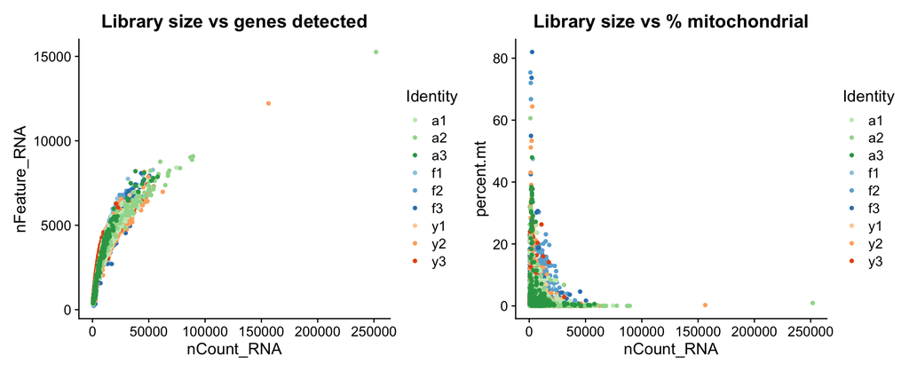

```r
p1 <- FeatureScatter(seu, "nCount_RNA", "nFeature_RNA", group.by = "sample",
                     cols = sample_cols) + ggtitle("Library size vs genes detected")
p2 <- FeatureScatter(seu, "nCount_RNA", "percent.mt", group.by = "sample",
                     cols = sample_cols) + ggtitle("Library size vs % mitochondrial")
p1 + p2
```

Before reading on, answer two questions from the plots:

1. Do all nine donors look alike?
2. Where would you put a mitochondrial cut-off?

## 2.2 What `percent.mt` actually looks like here

```r
summary(seu$percent.mt)
```

```
##    Min. 1st Qu.  Median    Mean 3rd Qu.    Max.
##  0.0000  0.1056  0.2544  1.5077  1.1447 81.9984
```

```r
# Per-donor: what fraction of nuclei would each candidate threshold remove?
sapply(c(1, 5, 10, 20), function(t) {
    round(100 * tapply(seu$percent.mt, seu$sample, function(z) mean(z >= t)), 1)
}) |> `colnames<-`(paste0("< ", c(1, 5, 10, 20)))
```

```
##     < 1  < 5 < 10 < 20
## a1 26.6  6.2  1.7  0.8
## a2 29.9  6.8  2.2  1.0
## a3 49.2 18.1 12.9  9.7
## f1  8.6  1.5  0.7  0.2
## f2 20.2 10.2  4.9  0.5
## f3 17.5  5.0  2.8  1.1
## y1 29.4  2.1  0.5  0.2
## y2 25.5  8.9  5.6  3.0
## y3 61.2  2.3  1.4  0.6
```

The median is around **0.25%**. That is very low — and it is low *because these are nuclei*. Mitochondria live in the cytoplasm, and the nuclei prep washes the cytoplasm away. A threshold carried over from a whole-cell dataset is answering a question this assay does not ask.

Now look across the rows of that table rather than down the columns.

### DECISION 1 — where do you cut? *(10 min)*

> Choose values for `min_genes`, `min_counts`, `max_counts` and `max_mt` below.

> Then answer, in writing, and be ready to defend it:
> 1. **How many nuclei did you lose, and from which donors?** Is the loss even?
> 2. A widely-copied tutorial default is `percent.mt < 5`. Look at that column in the table above. It removes about **6%** of nuclei overall — but **18% of donor `a3`** and **1.5% of donor `f1`**, a twelve-fold difference. Is that acceptable? What would it do to a later comparison of cell type composition between developmental stages — which is exactly what you will run in Practical 2?
> 3. Now look at the `< 1` column, where donor `y3` loses 61% of its nuclei and `f1` loses 9%. At what point does a quality threshold stop measuring quality and start measuring which donor a nucleus came from?
> 4. Would you use one global threshold, or a per-donor one? What is the cost of each?

> There is no marking scheme here. There is a defensible answer and an indefensible one, and the difference is whether you looked.

```r
# ---- YOUR VALUES ----
min_genes  <- 500
min_counts <- 2500
max_counts <- 40000
max_mt     <- 20
# ---------------------

n_before <- ncol(seu)
seu_filt <- subset(seu, subset = nFeature_RNA > min_genes &
                                 nCount_RNA  > min_counts &
                                 nCount_RNA  < max_counts &
                                 percent.mt  < max_mt)

cat("nuclei:", n_before, "->", ncol(seu_filt),
    sprintf("(%.1f%% removed)\n", 100 * (1 - ncol(seu_filt) / n_before)))
```

```
## nuclei: 7999 -> 6982 (12.7% removed)
```

```r
# Where did the losses fall? Index by name, so this still works if a donor
# loses every nucleus at an aggressive threshold.
before <- table(seu$sample)
after  <- table(factor(seu_filt$sample, levels = names(before)))
data.frame(
    before   = as.integer(before),
    after    = as.integer(after),
    pct_lost = round(100 * (1 - as.integer(after) / as.integer(before)), 1),
    row.names = names(before)
)
```

|  | before | after | pct_lost |
| --- | --- | --- | --- |
| a1 | 644 | 594 | 7.8 |
| a2 | 499 | 397 | 20.4 |
| a3 | 248 | 169 | 31.9 |
| f1 | 1226 | 1172 | 4.4 |
| f2 | 1618 | 1534 | 5.2 |
| f3 | 1258 | 1108 | 11.9 |
| y1 | 653 | 633 | 3.1 |
| y2 | 821 | 682 | 16.9 |
| y3 | 1032 | 693 | 32.8 |

### 🤖 What the agent chose here

> Given this dataset and **no instructions at all**, Claude Science picked **≥500 genes, ≥1000 UMI, `percent.mt < 10`** — and justified the last one like this:

> > *“mitochondrial fractions are uniformly low (donor medians 0.10–1.78%) **and** so are ribosomal fractions (0.4–1.3%). That combination points to a single-nucleus prep rather than whole cells.”*

> Nobody told it this was snRNA-seq. It worked that out from the data. It also flagged that donor `y3` has the shallowest library and that `a3` ends up with only ~200 cells — the same donor problem you just found.

> **Your question:** can you justify your threshold as well as that? Not “is your number the same” — is your *reason* as good?

> **HARD SYNC POINT.** Whatever you chose, run the chunk below now — including if your own filtering never ran. From here everyone works on an identical object, so the rest of the session lines up. Your own thresholds stay in your notes; we come back to them in the wrap-up.

```r
# Reference thresholds. Re-read from the original file so this works no matter
# what state your object is in.
seu <- readRDS(file.path(DATA, "P1_start.rds"))
seu <- subset(seu, subset = nFeature_RNA > 500 & nCount_RNA > 2500 &
                            nCount_RNA < 40000 & percent.mt < 20)
seu
```

```
## An object of class Seurat
## 18953 features across 6982 samples within 1 assay
## Active assay: RNA (18953 features, 0 variable features)
##  1 layer present: counts
```

# 3. Normalisation

Nuclei differ enormously in total counts, for reasons that have nothing to do with biology — capture efficiency, RNA content, sequencing depth. Normalisation removes that technical variation.

**SCTransform** models each gene’s counts with a regularised negative binomial and returns Pearson residuals. It handles the mean–variance relationship (highly expressed genes vary more, just from sampling) better than a simple log transform, and picks variable features as a side effect.

```r
seu <- SCTransform(seu, vst.flavor = "v2", seed.use = 42, verbose = FALSE)
```

```r
head(VariableFeatures(seu), 20)
```

```
##  [1] "F13A1"     "ACSM3"     "NRXN1"     "CNTNAP2"   "KAZN"      "XKR4"
##  [7] "NEGR1"     "LINC02388" "LDB2"      "PKHD1L1"   "CDH19"     "CSMD1"
## [13] "NRG1"      "C7"        "MRC1"      "CFH"       "KCNH7"     "NRXN3"
## [19] "OPCML"     "FMN1"
```

# 4. Dimension reduction

```r
seu <- RunPCA(seu, seed.use = 42, verbose = FALSE)
```

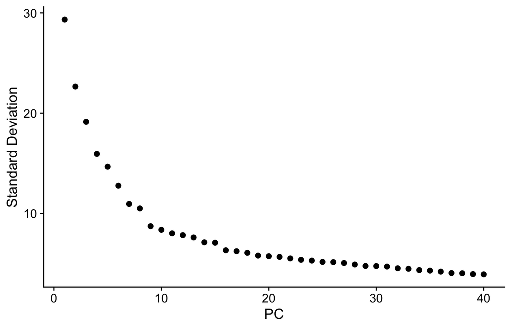

```r
ElbowPlot(seu, ndims = 40)
```

### DECISION 2 — how many PCs? *(8 min)*

> Pick `n_dims` from the elbow plot.
> 1. Where is the elbow? Do you and your neighbour agree to within 5?
> 2. What happens downstream if you take too **few**? Too **many**?
> 3. The elbow plot is a heuristic with no theoretical justification. What would a more principled choice look like, and why do you think almost nobody bothers?

```r
n_dims <- 20   # <- YOUR VALUE
```

# 5. Integration

Cells frequently cluster by *donor* rather than by *cell type*, because each sample carries its own technical signature. Look for that first:

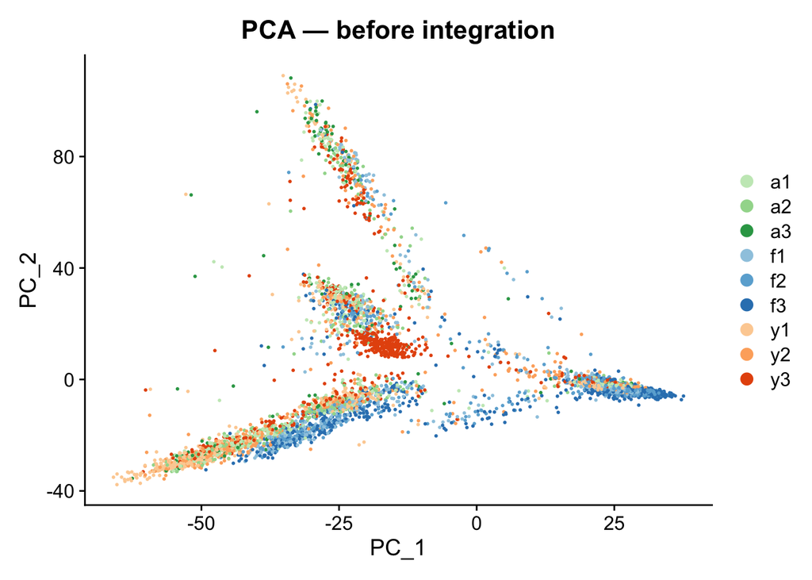

```r
DimPlot(seu, reduction = "pca", group.by = "sample", cols = sample_cols,
        shuffle = TRUE) + ggtitle("PCA — before integration")
```

**Harmony** iteratively projects cells into a shared embedding, clustering them softly and shifting each cluster to remove the donor-associated component while leaving the rest alone.

```r
set.seed(42)
seu <- RunHarmony(seu, group.by.vars = "sample", reduction.use = "pca",
                  dims.use = 1:n_dims, verbose = FALSE)
```

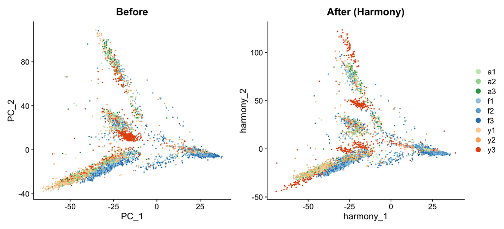

```r
p1 <- DimPlot(seu, reduction = "pca", group.by = "sample", cols = sample_cols,
              shuffle = TRUE) + ggtitle("Before") + NoLegend()
p2 <- DimPlot(seu, reduction = "harmony", group.by = "sample", cols = sample_cols,
              shuffle = TRUE) + ggtitle("After (Harmony)")
p1 + p2
```

**A warning worth more than the method.** “The donors mix better” is also what over-correction looks like — and over-correction destroys real biology. Here the donors differ by developmental stage, so *some* separation between them is exactly the signal we are trying to study. Integrating by `sample` rather than by `group` is a deliberate choice to remove donor effects while preserving stage effects.

So: can you check whether it worked?

## 5.1 A test for over-correction

> **Where this came from.** This check was not in the original version of this practical. It came from watching an AI agent analyse this exact dataset with no instructions — it invented this test, and it is better than the warning we used to give you here. Materials improve from wherever the good idea comes.

The argument has two halves, and you need both:

1. **Did integration remove the donor effect?** Count clusters dominated by a single donor, before and after. Should fall.
2. **Did it also remove the biology?** Count clusters restricted to a single developmental *stage*. Should **not** fall — because that is the signal.

If clusters stop being donor-specific but stay stage-specific, and each of those stage-specific clusters now draws on all three donors of that stage, the remaining structure is developmental rather than technical.

```r
# Self-contained: clusters both embeddings at a fixed resolution, so this does
# not depend on the resolution you pick in Decision 3. About 3 seconds.
check_res <- 0.4

dominated <- function(clusters, by, thr = 0.9) {
    tb <- table(clusters, by)
    frac <- apply(tb, 1, max) / rowSums(tb)
    c(clusters   = nrow(tb),
      dominated  = sum(frac >= thr),
      median_grp = median(apply(tb, 1, function(r) sum(r > 0))))
}

tmp <- FindNeighbors(seu, reduction = "pca", dims = 1:n_dims,
                     graph.name = c("p_nn", "p_snn"), verbose = FALSE)
tmp <- FindClusters(tmp, graph.name = "p_snn", resolution = check_res, verbose = FALSE)
before <- Idents(tmp)

tmp <- FindNeighbors(seu, reduction = "harmony", dims = 1:n_dims,
                     graph.name = c("h_nn", "h_snn"), verbose = FALSE)
tmp <- FindClusters(tmp, graph.name = "h_snn", resolution = check_res, verbose = FALSE)
after <- Idents(tmp)

rbind(`before integration` = dominated(before, seu$sample),
      `after Harmony`      = dominated(after,  seu$sample))
```

```
##                    clusters dominated median_grp
## before integration       18         4          6
## after Harmony            19         0          7
```

Donor-dominated clusters should collapse towards zero. Now the other half — did the biology survive?

```r
tb <- table(after, seu$group)
cat("clusters >=90% one developmental stage, after integration: ",
    sum(apply(tb, 1, max) / rowSums(tb) >= 0.9), " of ", nrow(tb), "\n", sep = "")
```

```
## clusters >=90% one developmental stage, after integration: 8 of 19
```

```r
rm(tmp)
```

Donor structure gone, stage structure intact. Unlike “the UMAP looks better”, that is a pair of numbers you can put in a methods section.

```r
seu <- RunUMAP(seu, reduction = "harmony", dims = 1:n_dims,
               seed.use = 42, verbose = FALSE)
```

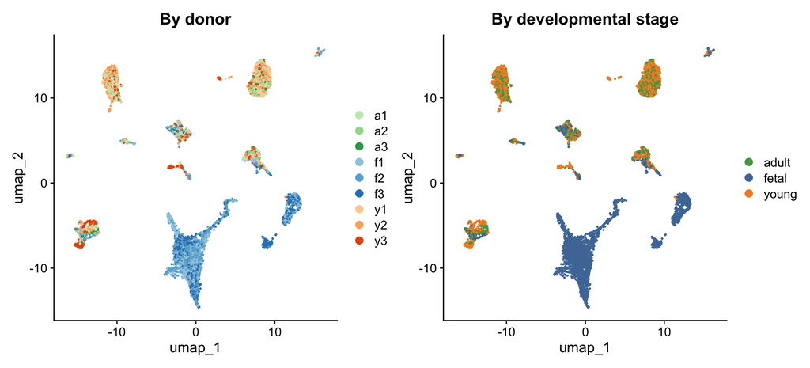

```r
p1 <- DimPlot(seu, reduction = "umap", group.by = "sample", cols = sample_cols,
              shuffle = TRUE) + ggtitle("By donor")
p2 <- DimPlot(seu, reduction = "umap", group.by = "group", cols = group_cols,
              shuffle = TRUE) + ggtitle("By developmental stage")
p1 + p2
```

Remember from the lecture: UMAP is for looking, not for measuring. Distances between clusters mean little, cluster areas mean nothing at all, and a cluster that looks isolated may not be.

# 6. Clustering

`FindNeighbors()` builds a shared-nearest-neighbour graph; `FindClusters()` runs Louvain community detection on it. The `resolution` parameter controls granularity, and it has no correct value — it depends on the question.

```r
seu <- FindNeighbors(seu, reduction = "harmony", dims = 1:n_dims, verbose = FALSE)
```

```r
resolutions <- c(0.1, 0.2, 0.3, 0.4, 0.6, 0.8)
set.seed(42)
for (r in resolutions) seu <- FindClusters(seu, resolution = r, verbose = FALSE)

sapply(resolutions, function(r)
    length(unique(seu@meta.data[[paste0("SCT_snn_res.", r)]]))) |>
    setNames(paste0("res ", resolutions))
```

```
## res 0.1 res 0.2 res 0.3 res 0.4 res 0.6 res 0.8
##      12      15      18      19      21      22
```

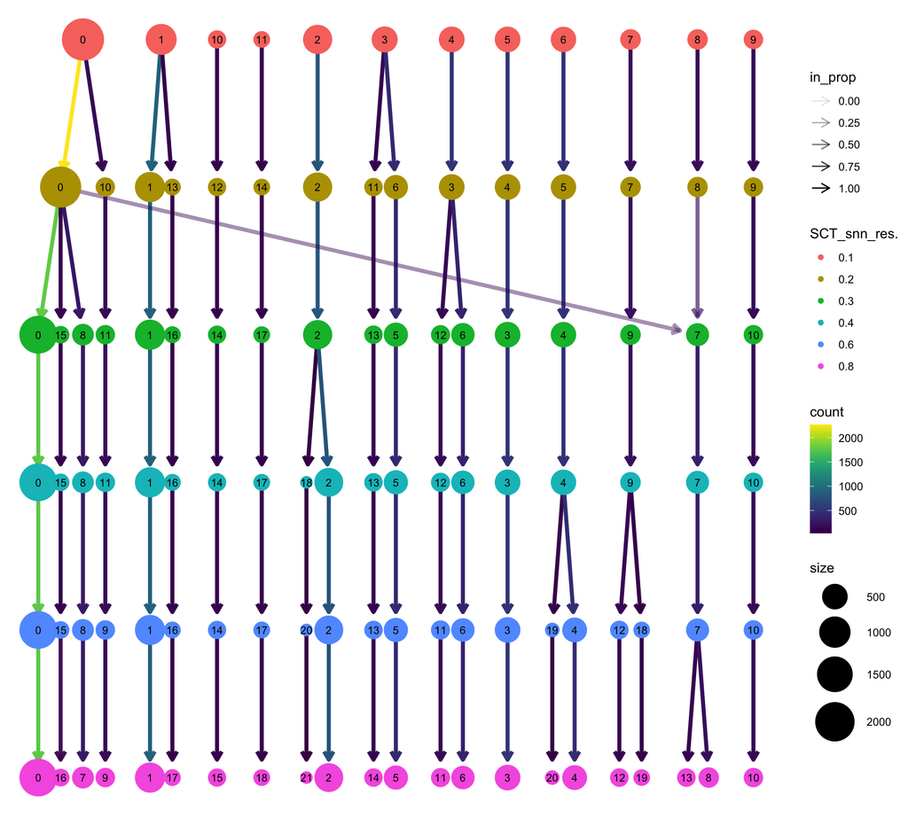

```r
clustree(seu, prefix = "SCT_snn_res.")
```

Reading a clustree: resolution increases downward. **Thick straight edges** mean a cluster is stable — the same cells stay together as resolution rises. **Thin, criss-crossing edges** mean cells are being shuffled between clusters, which usually means you are splitting a continuous population that has no natural division.

### DECISION 3 — how many clusters are real? *(11 min)*

```r
selected_res <- 0.4   # <- YOUR VALUE

Idents(seu) <- paste0("SCT_snn_res.", selected_res)
seu$seurat_clusters <- Idents(seu)
cat("clusters:", length(unique(seu$seurat_clusters)), "\n")
```

```
## clusters: 19
```

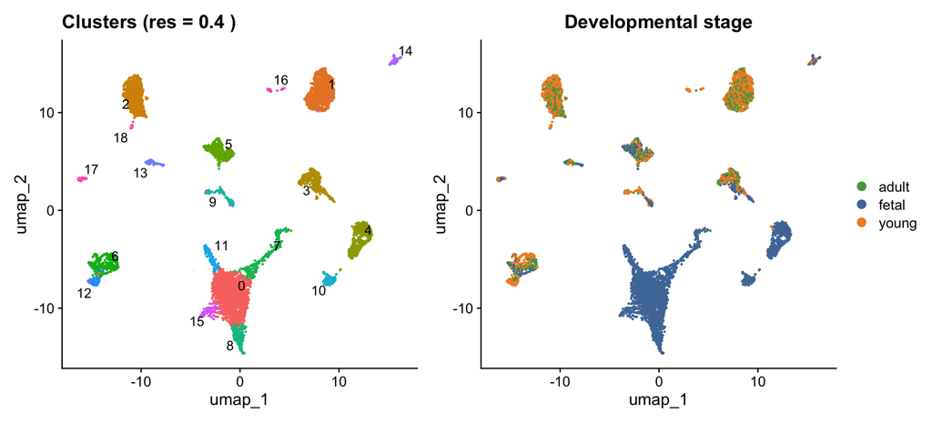

```r
p1 <- DimPlot(seu, reduction = "umap", label = TRUE, repel = TRUE) +
    NoLegend() + ggtitle(paste("Clusters (res =", selected_res, ")"))
p2 <- DimPlot(seu, reduction = "umap", group.by = "group", cols = group_cols,
              shuffle = TRUE) + ggtitle("Developmental stage")
p1 + p2
```

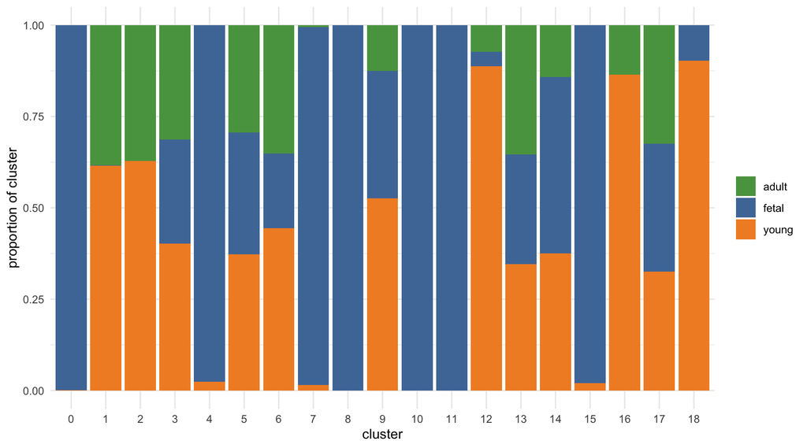

```r
seu@meta.data |>
    count(seurat_clusters, group) |>
    group_by(seurat_clusters) |>
    mutate(prop = n / sum(n)) |>
    ggplot(aes(seurat_clusters, prop, fill = group)) +
    geom_col() +
    scale_fill_manual(values = group_cols) +
    labs(x = "cluster", y = "proportion of cluster", fill = NULL) +
    theme_minimal()
```

### 🤖 What the agent chose here

> **Leiden at resolution 0.6**, against your Louvain at 0.4. Different algorithm, different resolution, different cluster count — on identical data.

> Neither is wrong. But notice that nothing in either analysis reports *“this number was a choice, and here is what it changes.”* You only know because you are holding both.

Several clusters are almost entirely foetal. That is real developmental biology, not a batch effect — foetal heart runs transcriptional programmes that the adult heart has switched off. It is also a warning: a clustering algorithm that splits strongly on developmental stage will happily split on any other strong covariate, including a technical one.

# 7. Save

```r
dir.create("results", showWarnings = FALSE)
saveRDS(seu, "results/my_02_integrated_clustered.rds")
```

Practical 2 starts from the shared checkpoint, not from your file, so the two sessions stay in step:

```r
seu <- readRDS(file.path(DATA, "checkpoints/02_integrated_clustered.rds"))
```

# What you decided

Write these down — we come back to them at the end of the day, and they are the shape of what your report needs to argue.

|  | Your value | Why |
| --- | --- | --- |
| QC thresholds |  |  |
| Number of PCs |  |  |
| Clustering resolution |  |  |

The pipeline ran identically whatever you chose. It would also have run identically if you had chosen badly. **Nothing in the output tells you which.**